# Transit Equity in Salt Lake County

- Show All Code
- Hide All Code
- View Source

A GIS-Based 2-Step Floating Catchment Area Accessibility Analysis of UTA-TRAX

This study examines whether UTA-TRAX light rail service in Salt Lake County, Utah equitably serves socially vulnerable populations. Using the Two-Step Floating Catchment Area (2SFCA) method and ACS 2015–2019 block group data, we construct a spatial accessibility index and evaluate its relationship with eight social equity indicators via spatial autoregressive models.

Authors

Affiliations

Faria Afrin Zinia

University of Utah, Department of City & Metropolitan Planning

Pukar Bhandari

University of Utah, Department of City & Metropolitan Planning

Justice Prosper Tuffour

University of Utah, Department of City & Metropolitan Planning

Andy Hong

University of Utah, Department of City & Metropolitan Planning

University of Utah, Healthy Aging and Resilient Places Lab

Published

May 4, 2022

Abstract

```r
library(tidyverse)
library(tidycensus)
library(sf)
library(tigris)
library(openrouteservice)  # ORS isochrones (GitHub: GIScience/openrouteservice-r)
library(mapgl)             # Interactive MapLibre GL maps (HTML output)
library(classInt)          # Jenks breaks for map classification
library(ggpubr)
library(scales)
library(ggspatial)         # annotation_scale / annotation_north_arrow
library(spdep)
library(spatialreg)
library(gtsummary)
library(gt)
library(broom)
library(knitr)
library(glue)

options(tigris_use_cache = TRUE)
```

# 1 Introduction

Public transit systems are often described as the foundational blood veins of a city — the infrastructure upon which education, healthcare, housing, and employment opportunities depend. The overarching goal of a transit network is to increase accessibility: the ability of people to reach the destinations that matter to their daily lives. Yet transit investment does not always accrue equally to all segments of the population.

The **UTA-TRAX** is an electric-powered light rail system serving the Salt Lake Valley of Utah. Operating on four major lines — the Blue, Red, Green, and S-Line — the network spans approximately 44.8 miles (72.1 km) with an annual ridership of about 19.7 million boardings. Despite this extensive reach, the critical question remains: *does UTA-TRAX adequately serve the county’s most socially vulnerable residents?*

This study directly addresses that question. Our central research question is:

> **“Does UTA-TRAX moderate social equity in Salt Lake County?”**

We establish the following hypotheses:

- **H₀ (Null):** Transit accessibility does not address equity by impacting social minorities.
- **H₁ (Alternative):** Transit accessibility addresses equity by impacting social minorities.

The study is contextualized within Salt Lake County and employs a 2-Step Floating Catchment Area (2SFCA) accessibility method to spatially quantify the relationship between TRAX station accessibility and eight social equity indicators derived from the American Community Survey (ACS). This report is the companion analytic document to the paper published in the *Transportation Research Record* ([DOI: 10.1177/03611981231170005](https://doi.org/10.1177/03611981231170005)).

## 1.1 Research Rationale

Cities across the United States are pursuing Mass Rapid Transit (MRT) and Transit-Oriented Development (TOD) strategies to combat traffic congestion, housing unaffordability, air pollution, and urban sprawl. Salt Lake County and the Wasatch Front Regional Council are similarly pursuing a polycentric development pattern anchored by the TRAX network.

Despite these transit-focused agendas, the Civil Rights Act of 1964, Title VI, prohibits federally funded transit providers from administering programs in ways that discriminate based on race, color, or national origin. There are legitimate public interest concerns about whether transit expansion genuinely serves minority and low-income communities, or whether it displaces them through gentrification. Empirically identifying and quantifying accessibility gaps for vulnerable groups is therefore essential for evidence-based, equitable planning.

# 2 Setup

## 2.1 API Configuration

This analysis requires two API keys:

1. **U.S. Census Bureau API** — for `tidycensus` data retrieval. Register at [api.census.gov](https://api.census.gov/data/key_signup.html).
2. **OpenRouteService (ORS) API** — for isochrone generation. Register at [openrouteservice.org](https://openrouteservice.org/dev/#/login).

```r
# Register Census API Key (run once; stores in ~/.Renviron)
census_api_key("YOUR_CENSUS_API_KEY", install = TRUE, overwrite = TRUE)
readRenviron("~/.Renviron")

# Register ORS API Key
ors_api_key("YOUR_ORS_API_KEY")
```

## 2.2 Project Data Paths

All spatial intermediate files (isochrones, shapefiles) are read from and written to a local `data/` folder. Adjust the path below to your local environment.

```r
# Relative path — place all raw shapefiles in data/raw/
path_raw  <- here::here("data", "raw")
path_proc <- here::here("data", "processed")

# Ensure processed directory exists
if (!dir.exists(path_proc)) dir.create(path_proc, recursive = TRUE)
```

# 3 Data Acquisition

## 3.1 Social Equity Variables from the American Community Survey

We use the ACS 5-year estimates (2015–2019) at the Census Block Group (CBG) level to capture demographic and socioeconomic characteristics within Salt Lake County. Block groups provide finer spatial resolution than tracts — critical for proximity-based accessibility analyses — while still providing reliable multi-year estimates.

Table 1: Social equity indicators, operational definitions, and ACS variable codes.

Social Equity Indicators and ACS Sources

| # | Indicator | Operational Definition | ACS Variable(s) |
| --- | --- | --- | --- |
| 1 | Household Income | % households with income < 80% of Area Median ($74,865) | B19001_002–011 |
| 2 | Race | % non-White population | B02001_003–008 |
| 3 | Ethnicity | % Hispanic or Latino population | B03003_003 |
| 4 | Age | % population aged <18 or >65 (dependent age groups) | B01001_003–006, 020–025, 027–030, 044–049 |
| 5 | Employment | % unemployed civilian labor force | B23025_004–005 |
| 6 | Education | % population ≥25 years with less than a high school diploma | B15003_002–016 |
| 7 | Vehicle Ownership | % households with no vehicle | B25044_003, 010 |
| 8 | House Ownership | % renter-occupied households | B25003_003 |

```r
# ACS variable vector — all raw variables needed for indicator construction
acs_vars <- c(
  # Population denominators
  total_pop    = "B02001_001",
  total_hh     = "B25003_001",
  total_age    = "B01001_001",
  total_income = "B19001_001",

  # Age: <18 (male)
  age1  = "B01001_003", age2  = "B01001_004",
  age3  = "B01001_005", age4  = "B01001_006",
  # Age: >65 (male)
  age5  = "B01001_020", age6  = "B01001_021",
  age7  = "B01001_022", age8  = "B01001_023",
  age9  = "B01001_024", age10 = "B01001_025",
  # Age: <18 (female)
  age11 = "B01001_027", age12 = "B01001_028",
  age13 = "B01001_029", age14 = "B01001_030",
  # Age: >65 (female)
  age15 = "B01001_044", age16 = "B01001_045",
  age17 = "B01001_046", age18 = "B01001_047",
  age19 = "B01001_048", age20 = "B01001_049",

  # Income: below $59,999 (proxy for <80% AMI @ $74,865)
  Inc1  = "B19001_002", Inc2  = "B19001_003",
  Inc3  = "B19001_004", Inc4  = "B19001_005",
  Inc5  = "B19001_006", Inc6  = "B19001_007",
  Inc7  = "B19001_008", Inc8  = "B19001_009",
  Inc9  = "B19001_010", Inc10 = "B19001_011",

  # Race
  pop_white   = "B02001_002", pop_black   = "B02001_003",
  pop_ameind  = "B02001_004", pop_asian   = "B02001_005",
  pop_native  = "B02001_006", pop_others  = "B02001_007",
  pop_2races  = "B02001_008",

  # Ethnicity
  pop_nonhisp  = "B03003_002",
  pop_hispanic = "B03003_003",

  # Vehicle ownership
  own_novehicle  = "B25044_003",  # Owner-occupied, no vehicle
  rent_novehicle = "B25044_010",  # Renter-occupied, no vehicle

  # Education (no diploma, 25+ yrs)
  pop_educ1  = "B15003_002", pop_educ2  = "B15003_003",
  pop_educ3  = "B15003_004", pop_educ4  = "B15003_005",
  pop_educ5  = "B15003_006", pop_educ6  = "B15003_007",
  pop_educ7  = "B15003_008", pop_educ8  = "B15003_009",
  pop_educ9  = "B15003_010", pop_educ10 = "B15003_011",
  pop_educ11 = "B15003_012", pop_educ12 = "B15003_013",
  pop_educ13 = "B15003_014", pop_educ14 = "B15003_015",
  pop_educ15 = "B15003_016",

  # Employment
  pop_employ = "B23025_004",  # Employed civilian labor force
  pop_unemp  = "B23025_005",  # Unemployed civilian labor force

  # Housing tenure
  hh_owner  = "B25003_002",
  hh_renter = "B25003_003"
)

slco_blockgrp <- get_acs(
  year        = 2019,
  survey      = "acs5",
  geography   = "block group",
  state       = "UT",
  county      = "Salt Lake",
  variables   = acs_vars,
  output      = "wide",
  geometry    = TRUE
) |>
  st_transform(3566)  # Utah Central State Plane (NAD83 / ft)
```

## 3.2 TRAX Station and Line Shapefiles

TRAX station point data and line shapefiles are sourced from the Utah Geospatial Resource Center (UGRC) and projected to the same coordinate reference system (EPSG 3566).

```r
trax_stn  <- st_read(file.path(path_raw, "LightRailStations_UTA_3566.shp"), quiet = TRUE)
trax_line <- st_read(file.path(path_raw, "LightRail_UTA_3566.shp"),         quiet = TRUE)

glue("TRAX Stations loaded: {nrow(trax_stn)} | CRS: {st_crs(trax_stn)$epsg}")
```

```
#> TRAX Stations loaded: 57 | CRS: 3566
```

# 4 Equity Indicator Construction

Each social equity indicator is expressed as a **percentage** of the relevant population or household denominator within each block group. This normalization allows meaningful comparisons across block groups of varying size.

> **Note on Indicator 5 (Employment):** The original script contained an operator-precedence error in the unemployment rate formula. The corrected formula uses explicit parentheses: `pop_unemp / (pop_employ + pop_unemp)`.

```r
slco_blockgrp <- slco_blockgrp |>
  mutate(
    # 1. Age: % of population in dependent age groups (<18 or >65)
    p_Age = (
      (age1E + age2E + age3E + age4E +           # Male <18
       age5E + age6E + age7E + age8E +            # Male 65–79
       age9E + age10E +                           # Male 80+
       age11E + age12E + age13E + age14E +        # Female <18
       age15E + age16E + age17E + age18E +        # Female 65–79
       age19E + age20E) / total_ageE              # Female 80+
    ) * 100,

    # 2. Income: % of households earning below 80% of SLCo AMI ($74,865)
    #    Brackets $0–$59,999 used as proxy (ACS top-codes income groups)
    p_Income = (
      (Inc1E + Inc2E + Inc3E + Inc4E + Inc5E +
       Inc6E + Inc7E + Inc8E + Inc9E + Inc10E) / total_incomeE
    ) * 100,

    # 3. Race: % non-White population
    p_Race = (
      (pop_blackE + pop_ameindE + pop_asianE +
       pop_nativeE + pop_othersE + pop_2racesE) / total_popE
    ) * 100,

    # 4. Ethnicity: % Hispanic or Latino population
    p_Ethnicity = (pop_hispanicE / total_popE) * 100,

    # 5. Employment: % unemployed of total civilian labor force (CORRECTED)
    p_Employment = (
      pop_unempE / (pop_employE + pop_unempE)
    ) * 100,

    # 6. Education: % aged 25+ without a high school diploma
    p_Education = (
      (pop_educ1E  + pop_educ2E  + pop_educ3E  + pop_educ4E  + pop_educ5E  +
       pop_educ6E  + pop_educ7E  + pop_educ8E  + pop_educ9E  + pop_educ10E +
       pop_educ11E + pop_educ12E + pop_educ13E + pop_educ14E + pop_educ15E) /
      total_popE
    ) * 100,

    # 7. Vehicle Ownership: % households with no vehicle (owners + renters)
    p_VOwnership = (
      (own_novehicleE + rent_novehicleE) / total_hhE
    ) * 100,

    # 8. House Ownership: % renter-occupied households
    p_HMOwnership = (hh_renterE / total_hhE) * 100
  )
```

## 4.1 Summary of Equity Indicators

```r
slco_blockgrp |>
  st_drop_geometry() |>
  select(
    `Age (Dependent)`        = p_Age,
    `Income (<80% AMI)`      = p_Income,
    `Race (Non-White)`       = p_Race,
    `Ethnicity (Hispanic)`   = p_Ethnicity,
    `Employment (Unemployed)`= p_Employment,
    `Education (No HS Dipl)` = p_Education,
    `Vehicle-Free HH`        = p_VOwnership,
    `Renter-Occupied HH`     = p_HMOwnership
  ) |>
  tbl_summary(
    statistic = list(all_continuous() ~ "{mean} ({sd}) [{min}–{max}]"),
    digits    = all_continuous() ~ 1,
    label     = list(
      `Age (Dependent)`         ~ "Age: Dependent (<18 or >65) (%)",
      `Income (<80% AMI)`       ~ "Household Income: <80% AMI (%)",
      `Race (Non-White)`        ~ "Race: Non-White (%)",
      `Ethnicity (Hispanic)`    ~ "Ethnicity: Hispanic/Latino (%)",
      `Employment (Unemployed)` ~ "Employment: Unemployed (%)",
      `Education (No HS Dipl)`  ~ "Education: No HS Diploma (%)",
      `Vehicle-Free HH`         ~ "Vehicle Ownership: No Vehicle (%)",
      `Renter-Occupied HH`      ~ "Housing: Renter-Occupied (%)"
    ),
    missing = "no"
  ) |>
  bold_labels() |>
  modify_caption("**Descriptive Statistics — Social Equity Indicators**") |>
  as_gt() |>
  opt_stylize(style = 6, color = "blue")
```

Table 2: Descriptive statistics for the eight social equity indicators across Salt Lake County block groups.

**Descriptive Statistics — Social Equity Indicators**

| **Characteristic** | **N = 612**<sup>1</sup> |
| --- | --- |
| Age: Dependent (<18 or >65) (%) | 37.1 (8.9) [4.0–61.3] |
| Household Income: <80% AMI (%) | 39.4 (19.1) [0.0–89.0] |
| Race: Non-White (%) | 20.1 (16.6) [0.0–86.6] |
| Ethnicity: Hispanic/Latino (%) | 17.8 (16.8) [0.0–81.7] |
| Employment: Unemployed (%) | 3.7 (3.4) [0.0–21.2] |
| Education: No HS Diploma (%) | 6.0 (5.9) [0.0–38.2] |
| Vehicle Ownership: No Vehicle (%) | 4.9 (6.9) [0.0–50.2] |
| Housing: Renter-Occupied (%) | 31.2 (25.4) [0.0–100.0] |

<sup>1</sup> Mean (SD) [Min–Max]

# 5 Supply and Demand: TRAX Catchment Isochrones

## 5.1 Methodology: Two-Step Floating Catchment Area (2SFCA)

The 2SFCA method quantifies spatial accessibility by combining *supply* (transit service capacity) and *demand* (population) within a shared catchment zone. The method proceeds in two steps:

**Step 1 — Supply Ratio:** For each TRAX station *j*, define a supply catchment as the 20-minute pedestrian isochrone. Sum the population of all block group centroids falling within that isochrone. Compute the supply ratio as:

$$R_j = \frac{S_j}{\sum_{k \in \{d_{kj} \leq d_0\}} P_k}$$

where $S_j$ is the service capacity of station $j$ (average riders × seating capacity) and $P_k$ is the population of block group $k$.

**Step 2 — Demand (Accessibility) Score:** For each block group centroid *i*, define a demand catchment as the 20-minute pedestrian isochrone. Sum the supply ratios of all TRAX stations falling within that catchment:

$$A_i = \sum_{j \in \{d_{ij} \leq d_0\}} R_j$$

Higher values of $A_i$ indicate greater transit accessibility.

## 5.2 Step 1: TRAX Station Isochrones (Supply Catchments)

TRAX station isochrones (20-minute foot-walking, 57 stations) are stored in `data/processed/trax_iso.shp` and loaded directly from disk. The ORS fallback only runs if the file is missing.

```r
trax_iso_path <- file.path(path_proc, "trax_iso.shp")

if (file.exists(trax_iso_path)) {
  trax_iso <- st_read(trax_iso_path, quiet = TRUE)
  message(glue("trax_iso loaded from disk ({nrow(trax_iso)} features)."))

} else {
  message("trax_iso.shp not found — running ORS API fallback.")

  trax_coords <- trax_stn |>
    st_transform(4326) |>
    st_coordinates()

  output_trax <- tibble()
  for (i in seq_len(nrow(trax_coords))) {
    cat(glue("  → Isochrone {i}/{nrow(trax_coords)}: {trax_stn$STATIONNAM[i]}\n"))
    res <- ors_isochrones(
      locations = trax_coords[i, ],
      range     = 20 * 60,
      profile   = "foot-walking",
      output    = "sf"
    )
    Sys.sleep(2)
    output_trax <- bind_rows(output_trax, res)
  }

  trax_iso <- output_trax |> select(-any_of("center"))
  st_write(trax_iso, trax_iso_path, quiet = TRUE)
  message("trax_iso computed and saved.")
}
```

```r
# Attach TRAX station attributes to isochrones and reproject
trax_catchment <- trax_iso |>
  mutate(
    OBJECTID   = trax_stn$OBJECTID,
    STATIONNAM = trax_stn$STATIONNAM,
    Boarding   = trax_stn$Boarding,
    Alighting  = trax_stn$Alighting,
    AvgRider   = trax_stn$AvgRider,
    ServCapaCT = trax_stn$ServCapaCT
  ) |>
  st_transform(3566)

# Block group centroids — always recomputed from slco_blockgrp in memory.
# Saving centroids to .shp would truncate long ACS column names (10-char limit),
# breaking downstream summarise() calls that reference e.g. total_popE.
blockgrp_centroid <- slco_blockgrp |> st_centroid()

# Spatial join: TRAX catchment polygons ∩ block group centroids → supply ratio
supply_ratio <- st_join(trax_catchment, blockgrp_centroid, left = FALSE) |>
  group_by(OBJECTID) |>
  summarise(
    sum_pop       = sum(total_popE, na.rm = TRUE),
    supply_ratio1 = first(ServCapaCT) / sum_pop,  # Capacity-based
    supply_ratio2 = first(AvgRider)   / sum_pop   # Ridership-based
  ) |>
  st_drop_geometry()

# Attach supply ratios back to TRAX station points
trax_to_pop <- left_join(trax_stn, supply_ratio, by = "OBJECTID") |>
  select(OBJECTID, STATIONNAM, supply_ratio1, supply_ratio2)
```

## 5.3 Step 2: Block Group Isochrones (Demand Catchments)

```r
blockgrp_iso_path <- file.path(path_proc, "blockgrp_iso.shp")

if (file.exists(blockgrp_iso_path)) {
  # Normal path: file already committed to data/processed/
  blockgrp_iso_combined <- st_read(blockgrp_iso_path, quiet = TRUE)
  message(glue("blockgrp_iso loaded from disk ({nrow(blockgrp_iso_combined)} features)."))

} else {
  # Fallback: recompute via ORS API (requires a valid ORS API key).
  # Runs in two batches to respect the API's per-minute rate limit.
  message("blockgrp_iso.shp not found — running ORS API fallback (this takes ~30 min).")

  blockgrp_coords <- blockgrp_centroid |>
    st_transform(4326) |>
    st_coordinates()

  run_batch <- function(idx) {
    out <- tibble()
    for (i in idx) {
      cat(glue("  → Block group isochrone {i}/{max(idx)}\n"))
      res <- ors_isochrones(
        locations = blockgrp_coords[i, ],
        range     = 20 * 60,
        profile   = "foot-walking",
        output    = "sf"
      )
      Sys.sleep(2)
      out <- bind_rows(out, res)
    }
    out
  }

  output1 <- run_batch(seq_len(min(350, nrow(blockgrp_coords))))
  output2 <- run_batch(seq(351, nrow(blockgrp_coords)))

  blockgrp_iso_combined <- bind_rows(output1, output2)
  st_write(blockgrp_iso_combined |> select(-any_of("center")),
           blockgrp_iso_path, quiet = TRUE)
  message("blockgrp_iso computed and saved.")
}
```

## 5.4 Computing the 2SFCA Accessibility Index

```r
# Use .rds (not .shp) to preserve all long ACS column names needed for
# regression (shapefile truncates field names to 10 characters).
tsfca_path <- file.path(path_proc, "TSFCA_Network.rds")

if (!file.exists(tsfca_path)) {
  # Attach block group attributes to demand catchment isochrones
  pop_catchment <- blockgrp_iso_combined |>
    mutate(
      GEOID     = blockgrp_centroid$GEOID,
      total_pop = blockgrp_centroid$total_popE
    ) |>
    st_transform(3566)

  # Spatial join: demand catchment ∩ supply ratios → accessibility score
  supply_demand_ratio <- st_join(pop_catchment, trax_to_pop) |>
    group_by(GEOID) |>
    summarise(
      access1 = sum(supply_ratio1, na.rm = TRUE),  # Capacity-based 2SFCA
      access2 = sum(supply_ratio2, na.rm = TRUE)   # Ridership-based 2SFCA
    ) |>
    st_drop_geometry()

  # Merge accessibility scores back into block group polygon layer
  TSFCA_network <- left_join(slco_blockgrp, supply_demand_ratio, by = "GEOID")
  saveRDS(TSFCA_network, tsfca_path)
  message("2SFCA accessibility computed and saved.")
} else {
  TSFCA_network <- readRDS(tsfca_path)
  message("TSFCA_Network loaded from disk.")
}
```

# 6 Accessibility Mapping (2SFCA)

The 2SFCA accessibility surface reveals pronounced spatial heterogeneity across Salt Lake County. Block groups surrounding downtown Salt Lake City, Sugarhouse, and portions of West Valley City exhibit the highest accessibility scores, largely because multiple TRAX stations are clustered in proximity — increasing supply ratios and expanding the overlap of pedestrian catchments.

```r
# Shared objects used by both the interactive and static maps.
# Defined once here so they are available throughout this section and
# in the LISA mapping section below.
slco_county <- tigris::counties(state = "UT", year = 2019, cb = TRUE) |>
  filter(NAME == "Salt Lake") |>
  st_transform(3566)

TSFCA_wgs84    <- TSFCA_network |> st_transform(4326)
trax_stn_wgs84 <- trax_stn      |> st_transform(4326)
```

```r
# Define the Jenks classification natively via mapgl
jenks_fill <- step_jenks(
  data    = TSFCA_wgs84,
  column  = "access1",
  colors  = c("#fff5f0", "#fc9272", "#fb6a4a", "#de2d26", "#a50f15"),
  n       = 5
)

maplibre(
  style  = carto_style("positron"),
  center = c(-111.891, 40.760),
  zoom   = 10
) |>
  add_fill_layer(
    id           = "2sfca-fill",
    source       = TSFCA_wgs84,
    fill_color   = jenks_fill$expression,
    fill_opacity = 0.75,
    tooltip      = "Accessibility: {access1}"
  ) |>
  add_line_layer(
    id           = "2sfca-outline",
    source       = TSFCA_wgs84,
    line_color   = "#ffffff",
    line_width   = 0.3,
    line_opacity = 0.5
  ) |>
  add_circle_layer(
    id                  = "trax-stations",
    source              = trax_stn_wgs84,
    circle_color        = "#0057b8",
    circle_radius       = 5,
    circle_stroke_color = "#ffffff",
    circle_stroke_width = 1.5
  ) |>
  add_legend(
    legend_title   = "2SFCA Accessibility",
    type           = "categorical",
    layer_id       = "2sfca-fill",
    classification = jenks_fill,
    interactive    = TRUE
  )
```

[interactive chart not shown]

Figure 1: Interactive map of 2SFCA transit accessibility scores across Salt Lake County block groups.

# 7 Correlation Analysis: Equity Indicators vs. Accessibility

Before fitting regression models, we examine bivariate relationships between each equity indicator and the 2SFCA accessibility score. Pearson correlation coefficients and significance tests provide an initial sense of which social groups are associated with higher or lower transit accessibility.

A positive correlation indicates that block groups with higher proportions of a given group tend to have *greater* TRAX accessibility — a potentially favorable equity outcome. A negative correlation suggests the system may be underserving that group.

```r
# Helper: build a ggplot correlation scatter for one indicator
corr_plot <- function(data, x_var, x_label, y_var = "access1",
                      y_label = "Transit Accessibility (2SFCA)") {
  data |>
    ggplot(aes(x = .data[[x_var]], y = .data[[y_var]])) +
    geom_point(alpha = 0.4, size = 1.2, color = "#3c6194") +
    geom_smooth(method = "lm", se = TRUE, color = "#c0392b", linewidth = 0.8) +
    stat_cor(
      aes(label = paste(after_stat(r.label), after_stat(p.label), sep = "~`,`~")),
      p.accuracy = 0.001,
      size = 3.5
    ) +
    labs(x = x_label, y = y_label) +
    theme_minimal(base_size = 10)
}
```

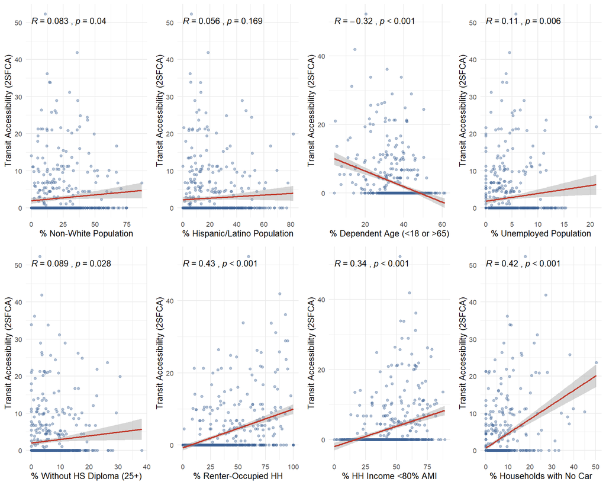

Figure 2: Bivariate correlation between each equity indicator and the 2SFCA transit accessibility score. Red line = OLS fit with 95% CI.

```r
p1 <- corr_plot(TSFCA_network, "p_Race",       "% Non-White Population")
p2 <- corr_plot(TSFCA_network, "p_Ethnicity",  "% Hispanic/Latino Population")
p3 <- corr_plot(TSFCA_network, "p_Age",        "% Dependent Age (<18 or >65)")
p4 <- corr_plot(TSFCA_network, "p_Employment", "% Unemployed Population")
p5 <- corr_plot(TSFCA_network, "p_Education",  "% Without HS Diploma (25+)")
p6 <- corr_plot(TSFCA_network, "p_HMOwnership","% Renter-Occupied HH")
p7 <- corr_plot(TSFCA_network, "p_Income",     "% HH Income <80% AMI")
p8 <- corr_plot(TSFCA_network, "p_VOwnership", "% Households with No Car")

ggarrange(p1, p2, p3, p4, p5, p6, p7, p8,
          ncol = 4, nrow = 2)
```

The correlation analysis reveals a significant positive association between transit accessibility and (1) the percentage of car-free households, (2) the percentage without a high school diploma, (3) households earning below 80% AMI, and (4) renter-occupied households. This suggests UTA-TRAX is *partially* serving transit-dependent and lower-income communities. However, the weaker correlation with the non-White population share may indicate residual spatial autocorrelation that a bivariate correlation cannot account for — motivating the spatial regression analysis below.

# 8 Spatial Autocorrelation (Moran’s I & LISA)

## 8.1 Rationale

The bivariate correlations and initial OLS residuals show strong positive skew and non-normality (confirmed by the histogram and Q-Q plot). This suggests the data violate the IID assumption of standard OLS, and that spatial dependency in the error structure is likely. We therefore proceed to formal spatial autocorrelation testing using Moran’s I.

## 8.2 Spatial Weights Matrix

We use **Queen’s contiguity** to define neighbors — two block groups are neighbors if they share any boundary point (edge or vertex). Weights are row-standardized.

```r
# Clean out NaN/NA values created by 0/0 division in ACS demographics
# This MUST happen before building spatial weights to ensure perfect alignment
TSFCA_network <- TSFCA_network |>
  filter(if_all(c(access1, starts_with("p_")), ~ !is.na(.) & !is.nan(.)))

# Now build the spatial weights on the clean dataset
queen   <- poly2nb(TSFCA_network, queen = TRUE)
weights <- nb2listw(neighbours = queen, style = "W", zero.policy = TRUE)

cat(glue(
  "Neighbors object: {length(queen)} block groups\n",
  "Average neighbors per unit: {mean(card(queen)) |> round(2)}\n"
))
```

```
#> Neighbors object: 610 block groups
#> Average neighbors per unit: 6.67
```

## 8.3 Queen Contiguity Network

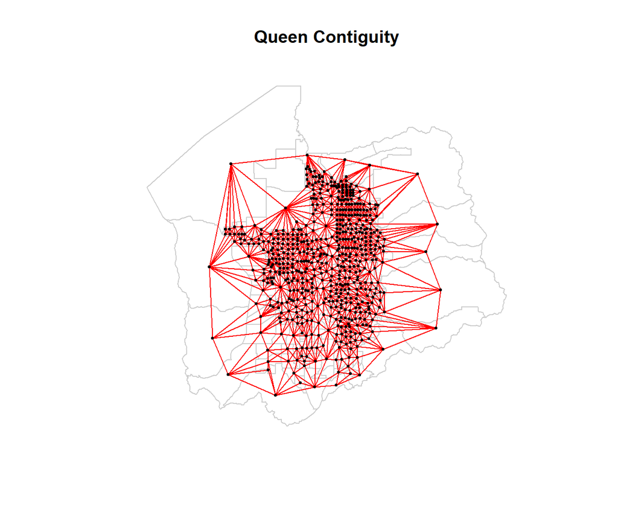

Figure 3: Queen contiguity neighbor network for Salt Lake County block groups. Red lines connect neighboring units.

```r
blockgrp_centr <- st_centroid(st_geometry(TSFCA_network),
                               of_largest_polygon = TRUE)

plot(st_geometry(TSFCA_network), border = "grey80", main = "Queen Contiguity")
plot(queen, blockgrp_centr, pch = 19, cex = 0.4, col = "red", add = TRUE)
```

## 8.4 Global Moran’s I

```r
# Parametric Moran's I test
moran_test <- moran.test(TSFCA_network$access1,
                         listw     = weights,
                         zero.policy = TRUE)

# Monte Carlo simulation (999 permutations)
moran_mc <- moran.mc(TSFCA_network$access1,
                     listw     = weights,
                     nsim      = 999,
                     zero.policy = TRUE)
```

```r
tibble(
  Test       = c("Moran's I (parametric)", "Moran's I (Monte Carlo, 999 sim)"),
  Statistic  = c(moran_test$statistic, moran_mc$statistic),
  `p-value`  = c(moran_test$p.value, moran_mc$p.value)
) |>
  gt() |>
  fmt_number(columns = c(Statistic, `p-value`), decimals = 4) |>
  tab_header(title = "Global Moran's I — TRAX Accessibility") |>
  opt_stylize(style = 6, color = "blue")
```

Table 3: Global Moran’s I — TRAX Accessibility

Global Moran's I — TRAX Accessibility

| Test | Statistic | p-value |
| --- | --- | --- |
| Moran's I (parametric) | 31.1809 | 0.0000 |
| Moran's I (Monte Carlo, 999 sim) | 0.6888 | 0.0010 |

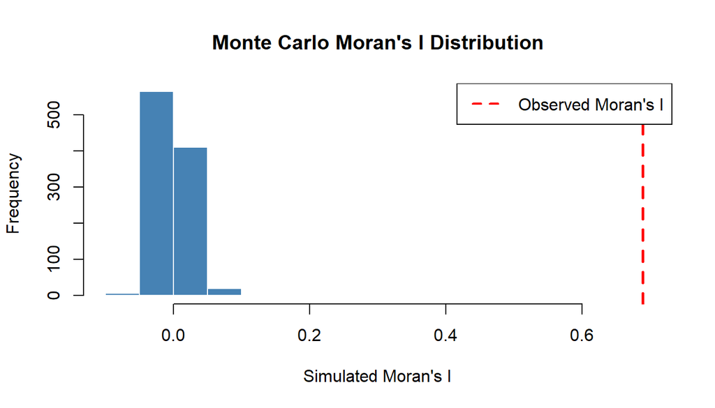

Figure 4: Distribution of simulated Moran’s I values under spatial randomness (999 permutations). The observed value far exceeds the null distribution.

```r
hist(moran_mc$res, freq = TRUE, breaks = 25,
     xlab = "Simulated Moran's I", main = "Monte Carlo Moran's I Distribution",
     col = "steelblue", border = "white")
abline(v = moran_mc$statistic, col = "red", lwd = 2.5, lty = 2)
legend("topright", legend = c("Observed Moran's I"),
       col = "red", lty = 2, lwd = 2)
```

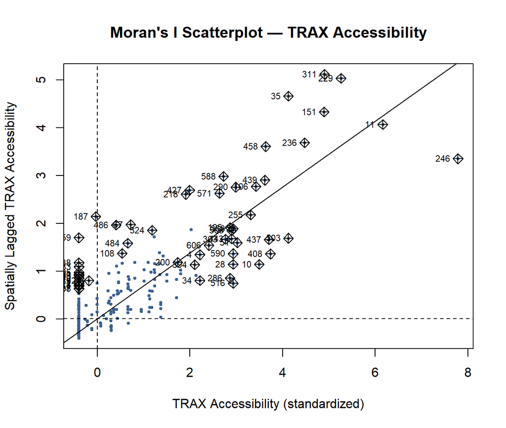

Figure 5: Moran’s I scatterplot. The positive slope confirms spatial clustering — block groups with high accessibility tend to neighbor other high-accessibility block groups.

```r
TSFCA_network$zscore <- as.numeric(scale(TSFCA_network$access1))

moran.plot(
  TSFCA_network$zscore, listw = weights,
  pch  = 19, cex  = 0.5, col  = "#3c6194",
  main = "Moran's I Scatterplot — TRAX Accessibility",
  xlab = "TRAX Accessibility (standardized)",
  ylab = "Spatially Lagged TRAX Accessibility"
)
```

## 8.5 Local Moran’s I (LISA)

Local Indicators of Spatial Association (LISA) decompose the global statistic to identify specific hot spots and cold spots of accessibility clustering.

```r
# Use .rds to preserve column names (LISA category string would survive .shp
# but other inherited columns from TSFCA_network would be truncated).
lisa_path <- file.path(path_proc, "LISA.rds")

if (!file.exists(lisa_path)) {
  LISA <- TSFCA_network |>
    mutate(
      moran_p = localmoran(access1, listw = weights,
                           zero.policy = TRUE)[, 5],
      zscore  = as.numeric(scale(access1)),
      lagged  = lag.listw(zscore, x = weights),
      LISA    = if_else(
        zscore >= 0 & lagged >= 0 & moran_p <= 0.05,
        "High-High Cluster",
        "No Significant Cluster"
      )
    )
  saveRDS(LISA, lisa_path)
  message("LISA clusters computed and saved.")
} else {
  LISA <- readRDS(lisa_path)
  message("LISA loaded from disk.")
}

cat(glue(
  "High-High Clusters: {sum(LISA$LISA == 'High-High Cluster', na.rm=TRUE)}\n",
  "No Cluster:         {sum(LISA$LISA == 'No Significant Cluster', na.rm=TRUE)}\n"
))
```

[output not shown]

## 8.6 LISA Cluster Map

```r
LISA_wgs84 <- LISA |> st_transform(4326)

maplibre(
  style  = carto_style("positron"),
  center = c(-111.891, 40.760),
  zoom   = 10
) |>
  add_fill_layer(
    id     = "lisa-fill",
    source = LISA_wgs84,
    fill_color = match_expr(
      column  = "LISA",
      values  = c("High-High Cluster", "No Significant Cluster"),
      stops   = c("#e41a1c", "#d9d9d9"),
      default = "#d9d9d9"
    ),
    fill_opacity = 0.75,
    tooltip      = "<b>LISA:</b> {LISA}"
  ) |>
  add_line_layer(
    id         = "lisa-outline",
    source     = LISA_wgs84,
    line_color = "#ffffff",
    line_width = 0.3
  ) |>
  add_circle_layer(
    id                  = "trax-stations-lisa",
    source              = trax_stn_wgs84,
    circle_color        = "#0057b8",
    circle_radius       = 5,
    circle_stroke_color = "#ffffff",
    circle_stroke_width = 1.5
  ) |>
  add_categorical_legend(
    legend_title  = "LISA Cluster",
    values        = c("High-High Cluster", "No Significant Cluster"),
    colors        = c("#e41a1c", "#d9d9d9"),
    layer_id      = "lisa-fill",
    filter_column = "LISA",
    interactive   = TRUE
  )
```

[interactive chart not shown]

Figure 6: Interactive LISA cluster map. Red polygons are statistically significant High-High accessibility clusters (p ≤ 0.05, Queen contiguity).

# 9 Spatial Regression Models

## 9.1 OLS Residual Diagnostics

Before fitting spatial autoregressive models, we estimate a baseline OLS regression to assess whether its assumptions are satisfied.

```r
Model1.OLS <- lm(
  access1 ~ p_Race + p_Ethnicity + p_Employment + p_Age +
            p_Education + p_HMOwnership + p_Income + p_VOwnership,
  data = TSFCA_network
)
```

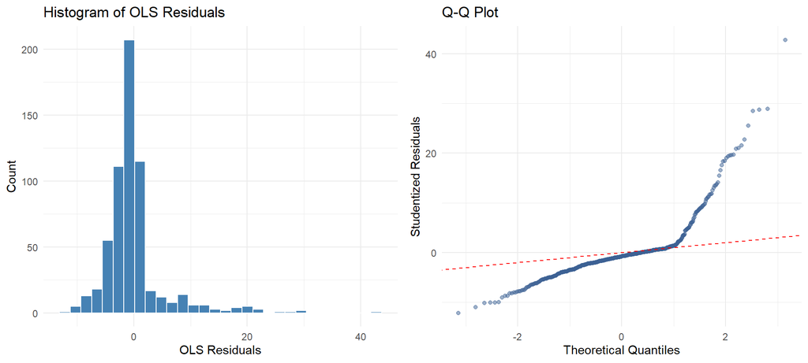

Figure 7: OLS residual diagnostics. Left: Histogram of residuals showing strong positive skew. Right: Q-Q plot showing departures from normality in the tails.

```r
p_hist <- ggplot() +
  geom_histogram(aes(x = resid(Model1.OLS)), bins = 30,
                 fill = "steelblue", color = "white") +
  labs(x = "OLS Residuals", y = "Count",
       title = "Histogram of OLS Residuals") +
  theme_minimal()

# car::qqPlot returns a base-graphics plot; we capture it
p_qq <- ggplot(
  data = data.frame(
    theoretical = qqnorm(resid(Model1.OLS), plot.it = FALSE)$x,
    sample      = qqnorm(resid(Model1.OLS), plot.it = FALSE)$y
  ),
  aes(x = theoretical, y = sample)
) +
  geom_point(alpha = 0.5, color = "#3c6194") +
  geom_abline(slope = 1, intercept = 0, color = "red", linetype = "dashed") +
  labs(x = "Theoretical Quantiles", y = "Studentized Residuals",
       title = "Q-Q Plot") +
  theme_minimal()

ggarrange(p_hist, p_qq, ncol = 2)
```

The residual histogram is strongly right-skewed, and the Q-Q plot shows substantial departures from normality in the upper tail — particularly for the high-accessibility downtown cluster. This confirms that the data violate the IID assumption, justifying the use of spatial autoregressive models.

```r
# Moran's I on OLS residuals
lm.morantest(Model1.OLS, listw = weights, zero.policy = TRUE)
```

```
#>
#>  Global Moran I for regression residuals
#>
#> data:
#> model: lm(formula = access1 ~ p_Race + p_Ethnicity + p_Employment +
#> p_Age + p_Education + p_HMOwnership + p_Income + p_VOwnership, data =
#> TSFCA_network)
#> weights: weights
#>
#> Moran I statistic standard deviate = 23.704, p-value < 2.2e-16
#> alternative hypothesis: greater
#> sample estimates:
#> Observed Moran I      Expectation         Variance
#>     0.5214114985    -0.0045562739     0.0004923672
```

## 9.2 Model 1: OLS Regression

```r
tbl_regression(
  Model1.OLS,
  label = list(
    p_Race        ~ "Race: % Non-White",
    p_Ethnicity   ~ "Ethnicity: % Hispanic",
    p_Employment  ~ "Employment: % Unemployed",
    p_Age         ~ "Age: % Dependent (<18 or >65)",
    p_Education   ~ "Education: % Without HS Diploma",
    p_HMOwnership ~ "Housing: % Renter-Occupied",
    p_Income      ~ "Income: % HH <80% AMI",
    p_VOwnership  ~ "Vehicle: % No-Car HH"
  ),
  intercept = TRUE,
  estimate_fun = ~ style_sigfig(.x, digits = 3),
  pvalue_fun   = ~ style_pvalue(.x, digits = 3)
) |>
  add_glance_source_note(
    include = c(r.squared, adj.r.squared, statistic, p.value, nobs)
  ) |>
  bold_p(t = 0.05) |>
  bold_labels() |>
  modify_caption("**Model 1: OLS Regression** — Dependent variable: 2SFCA Accessibility") |>
  as_gt() |>
  opt_stylize(style = 6, color = "blue")
```

Table 4: OLS regression results: 2SFCA accessibility regressed on eight social equity indicators.

**Model 1: OLS Regression** — Dependent variable: 2SFCA Accessibility

| **Characteristic** | **Beta** | **95% CI** | **p-value** |
| --- | --- | --- | --- |
| (Intercept) | 3.77 | 1.16, 6.38 | 0.005 |
| Race: % Non-White | -0.028 | -0.076, 0.019 | 0.242 |
| Ethnicity: % Hispanic | 0.005 | -0.047, 0.057 | 0.857 |
| Employment: % Unemployed | 0.122 | -0.018, 0.262 | 0.088 |
| Age: % Dependent (<18 or >65) | -0.115 | -0.174, -0.056 | <0.001 |
| Education: % Without HS Diploma | -0.009 | -0.135, 0.118 | 0.893 |
| Housing: % Renter-Occupied | 0.044 | 0.013, 0.075 | 0.005 |
| Income: % HH <80% AMI | 0.016 | -0.025, 0.056 | 0.454 |
| Vehicle: % No-Car HH | 0.240 | 0.158, 0.321 | <0.001 |

Abbreviation: CI = Confidence Interval  
R² = 0.252; Adjusted R² = 0.242; Statistic = 25.4; p-value = <0.001; No. Obs. = 610

The OLS model explains only about 24.2% of the variance in 2SFCA accessibility (Adjusted R² ≈ 0.242). Statistically significant predictors include the dependent age group percentage (negative), renter-occupied household percentage (positive), and vehicle-free household percentage (positive). Given the confirmed spatial autocorrelation, the OLS estimates are likely biased and inefficient.

## 9.3 Model 2: Spatial Lag Model (SLM)

The Spatial Lag Model accounts for spatial dependency in the **dependent variable** — here, the accessibility of neighboring block groups directly influences a given block group’s accessibility score. This is theoretically appropriate because transit catchments spatially overlap.

```r
Model2.SLM <- lagsarlm(
  access1 ~ p_Race + p_Ethnicity + p_Employment + p_Age +
            p_Education + p_HMOwnership + p_Income + p_VOwnership,
  data   = TSFCA_network,
  listw  = weights,
  zero.policy = TRUE
)
```

## 9.4 Model 3: Spatial Error Model (SEM)

The Spatial Error Model captures spatial dependency in the **error term** — unobserved factors (e.g., land use patterns, built environment) that cluster spatially and influence accessibility but are not explicitly measured.

```r
Model3.SEM <- errorsarlm(
  access1 ~ p_Race + p_Ethnicity + p_Employment + p_Age +
            p_Education + p_HMOwnership + p_Income + p_VOwnership,
  data   = TSFCA_network,
  listw  = weights,
  zero.policy = TRUE
)
```

## 9.5 Model Comparison

```r
# Extract tidy coefficients for both spatial models
tidy_slm <- broom::tidy(Model2.SLM) |>
  mutate(model = "Spatial Lag (SLM)")

tidy_sem <- broom::tidy(Model3.SEM) |>
  mutate(model = "Spatial Error (SEM)")

# AIC comparison table
tibble(
  Model           = c("OLS", "Spatial Lag (SLM)", "Spatial Error (SEM)"),
  `Log-Likelihood`= c(logLik(Model1.OLS)[1],
                       logLik(Model2.SLM)[1],
                       logLik(Model3.SEM)[1]),
  AIC             = c(AIC(Model1.OLS),
                       AIC(Model2.SLM),
                       AIC(Model3.SEM)),
  `Adj. R² / Pseudo R²` = c(
    summary(Model1.OLS)$adj.r.squared,
    summary(Model2.SLM)$NK$NK,    # Nagelkerke pseudo-R²
    summary(Model3.SEM)$NK$NK
  )
) |>
  mutate(across(where(is.numeric), \(x) round(x, 2))) |>
  gt() |>
  tab_header(title = "Model Performance Comparison") |>
  tab_style(
    style = cell_fill(color = "#d4edda"),
    locations = cells_body(rows = AIC == min(AIC))
  ) |>
  opt_stylize(style = 6, color = "blue")
```

Table 5: Comparison of OLS, Spatial Lag Model (SLM), and Spatial Error Model (SEM) by AIC and Log-Likelihood.

Model Performance Comparison

| Model | Log-Likelihood | AIC | Adj. R² / Pseudo R² |
| --- | --- | --- | --- |
| OLS | -1908.20 | 3836.40 | 0.24 |
| Spatial Lag (SLM) | -1641.95 | 3305.91 | 0.24 |
| Spatial Error (SEM) | -1650.23 | 3322.46 | 0.24 |

```r
bind_rows(tidy_slm, tidy_sem) |>
  filter(!term %in% c("rho", "lambda")) |>
  select(model, term, estimate, std.error, statistic, p.value) |>
  mutate(
    term = recode(term,
      `(Intercept)`  = "Intercept",
      p_Race         = "Race: % Non-White",
      p_Ethnicity    = "Ethnicity: % Hispanic",
      p_Employment   = "Employment: % Unemployed",
      p_Age          = "Age: % Dependent",
      p_Education    = "Education: % Without HS Diploma",
      p_HMOwnership  = "Housing: % Renter-Occupied",
      p_Income       = "Income: % HH <80% AMI",
      p_VOwnership   = "Vehicle: % No-Car HH"
    ),
    sig = case_when(
      p.value < 0.001 ~ "***",
      p.value < 0.01  ~ "**",
      p.value < 0.05  ~ "*",
      p.value < 0.10  ~ ".",
      TRUE            ~ ""
    )
  ) |>
  gt(groupname_col = "model") |>
  fmt_number(columns = c(estimate, std.error, statistic), decimals = 4) |>
  fmt_number(columns = p.value, decimals = 4) |>
  cols_label(
    term      = "Variable",
    estimate  = "Estimate",
    std.error = "Std. Error",
    statistic = "z-value",
    p.value   = "p-value",
    sig       = ""
  ) |>
  tab_style(
    style     = cell_text(weight = "bold"),
    locations = cells_body(rows = p.value < 0.05, columns = c(term, estimate, sig))
  ) |>
  tab_footnote(
    footnote  = "Significance: *** p<0.001, ** p<0.01, * p<0.05, . p<0.10",
    locations = cells_column_labels(columns = sig)
  ) |>
  opt_stylize(style = 6, color = "blue")
```

Table 6: Coefficient estimates for the Spatial Lag and Spatial Error models.

| Variable | Estimate | Std. Error | z-value | p-value | <sup>1</sup> |
| --- | --- | --- | --- | --- | --- |
| Spatial Lag (SLM) |  |  |  |  |  |
| Intercept | 0.5850 | 0.7857 | 0.7446 | 0.4565 |  |
| Race: % Non-White | −0.0086 | 0.0142 | −0.6051 | 0.5451 |  |
| Ethnicity: % Hispanic | −0.0066 | 0.0155 | −0.4248 | 0.6710 |  |
| Employment: % Unemployed | 0.0693 | 0.0418 | 1.6575 | 0.0974 | . |
| Age: % Dependent | −0.0219 | 0.0177 | −1.2358 | 0.2165 |  |
| Education: % Without HS Diploma | −0.0090 | 0.0376 | −0.2403 | 0.8101 |  |
| Housing: % Renter-Occupied | 0.0112 | 0.0092 | 1.2173 | 0.2235 |  |
| Income: % HH <80% AMI | −0.0019 | 0.0122 | −0.1559 | 0.8761 |  |
| Vehicle: % No-Car HH | 0.0712 | 0.0243 | 2.9245 | 0.0035 | ** |
| Spatial Error (SEM) |  |  |  |  |  |
| Intercept | 3.8612 | 1.7181 | 2.2473 | 0.0246 | * |
| Race: % Non-White | −0.0151 | 0.0156 | −0.9719 | 0.3311 |  |
| Ethnicity: % Hispanic | −0.0132 | 0.0148 | −0.8949 | 0.3709 |  |
| Employment: % Unemployed | 0.0442 | 0.0397 | 1.1147 | 0.2650 |  |
| Age: % Dependent | −0.0316 | 0.0196 | −1.6129 | 0.1068 |  |
| Education: % Without HS Diploma | −0.0098 | 0.0378 | −0.2607 | 0.7943 |  |
| Housing: % Renter-Occupied | 0.0133 | 0.0094 | 1.4179 | 0.1562 |  |
| Income: % HH <80% AMI | −0.0099 | 0.0133 | −0.7405 | 0.4590 |  |
| Vehicle: % No-Car HH | 0.0467 | 0.0248 | 1.8782 | 0.0603 | . |

<sup>1</sup> Significance: *** p<0.001, ** p<0.01, * p<0.05, . p<0.10

## 9.6 Best Model: Spatial Lag Model Interpretation

The Spatial Lag Model (AIC = 3305.9) outperforms both OLS (AIC = 3836.4) and the Spatial Error Model (AIC = 3322.5), providing the most efficient fit to the data.

```r
# Direct, indirect, and total impacts for the SLM
slm_impacts <- spatialreg::impacts(
  obj      = Model2.SLM,
  listw    = weights,
  zero.policy = TRUE,
  R        = 500
)

summary(slm_impacts, zstats = TRUE, short = TRUE)
```

```
#> Impact measures (lag, exact):
#>                           Direct    Indirect       Total
#> p_Race dy/dx        -0.011159263 -0.05836418 -0.06952344
#> p_Ethnicity dy/dx   -0.008540940 -0.04467006 -0.05321100
#> p_Employment dy/dx   0.089946056  0.47042784  0.56037390
#> p_Age dy/dx         -0.028478748 -0.14894701 -0.17742576
#> p_Education dy/dx   -0.011745003 -0.06142767 -0.07317267
#> p_HMOwnership dy/dx  0.014554640  0.07612238  0.09067702
#> p_Income dy/dx      -0.002463372 -0.01288371 -0.01534708
#> p_VOwnership dy/dx   0.092447996  0.48351327  0.57596126
#> ========================================================
#> Simulation results ( variance matrix):
#> ========================================================
#> Simulated standard errors
#>                         Direct   Indirect      Total
#> p_Race dy/dx        0.01831016 0.10076840 0.11875587
#> p_Ethnicity dy/dx   0.01978711 0.10915805 0.12858279
#> p_Employment dy/dx  0.05329649 0.31551599 0.36651869
#> p_Age dy/dx         0.02417690 0.13438857 0.15775315
#> p_Education dy/dx   0.04985524 0.27487525 0.32399240
#> p_HMOwnership dy/dx 0.01224030 0.06686620 0.07865191
#> p_Income dy/dx      0.01589897 0.08690543 0.10258931
#> p_VOwnership dy/dx  0.03078625 0.18990986 0.21719599
#>
#> Simulated z-values:
#>                         Direct   Indirect      Total
#> p_Race dy/dx        -0.5850151 -0.5778042 -0.5804860
#> p_Ethnicity dy/dx   -0.4573903 -0.4439739 -0.4472897
#> p_Employment dy/dx   1.6407574  1.5027113  1.5321894
#> p_Age dy/dx         -1.1660833 -1.0971719 -1.1133828
#> p_Education dy/dx   -0.1888307 -0.1707368 -0.1739100
#> p_HMOwnership dy/dx  1.2076736  1.1731237  1.1852810
#> p_Income dy/dx      -0.1952493 -0.1994186 -0.1991906
#> p_VOwnership dy/dx   2.9721268  2.5859471  2.6823584
#>
#> Simulated p-values:
#>                     Direct    Indirect  Total
#> p_Race dy/dx        0.5585376 0.5633963 0.5615869
#> p_Ethnicity dy/dx   0.6473906 0.6570615 0.6546659
#> p_Employment dy/dx  0.1008478 0.1329135 0.1254757
#> p_Age dy/dx         0.2435808 0.2725663 0.2655441
#> p_Education dy/dx   0.8502255 0.8644308 0.8619362
#> p_HMOwnership dy/dx 0.2271728 0.2407462 0.2359064
#> p_Income dy/dx      0.8451978 0.8419353 0.8421137
#> p_VOwnership dy/dx  0.0029574 0.0097112 0.0073105
```

# 10 Discussion and Conclusions

## 10.2 Policy Recommendations

- **Expand pedestrian catchments.** Investments in sidewalk infrastructure, protected bike lanes, and first/last-mile connections (e.g., bike-share, micro-mobility) near TRAX stations in underserved southern and western Salt Lake County could significantly expand effective accessibility for equity populations.
- **Targeted service frequency increases.** High-demand equity corridors — particularly areas with elevated concentrations of non-White residents and low-income households that currently fall outside the 20-minute catchment — should be candidates for new bus routes or more frequent TRAX service.
- **Integrate Title VI monitoring.** UTA should adopt spatially explicit equity metrics, such as the 2SFCA accessibility index, into its ongoing Title VI compliance reporting, enabling proactive identification of disparities before they crystallize.
- **Revisit the AMI threshold.** The income bracket proxy used here ($0–$59,999 for <80% AMI) may undercount households in the 60th–80th percentile of income. Future analyses should use the continuous income distribution from PUMS data for a more precise low-income definition.

## 10.4 Future Work

Future research should: (1) incorporate GTFS-based temporal accessibility to capture off-peak and weekend service gaps; (2) apply the 2SFCA method to other transit modes (bus, FrontRunner commuter rail) for a system-wide equity picture; and (3) use longitudinal ACS data to track how accessibility equity has changed alongside TRAX network expansions.

*This analysis was conducted as part of CMP 6455 — Advanced GIS Applications, University of Utah, Department of City & Metropolitan Planning. The companion publication is available at [DOI: 10.1177/03611981231170005](https://doi.org/10.1177/03611981231170005).*